# PD1

Hanna Zdulska

3/10/2020

# 1 Zbiór

Do analizy posłuży nam zbiór irish ze strony [openml](https://www.openml.org/d/451)

Irish Educational Transitions Data Data on educational transitions for a sample of 500 Irish schoolchildren aged 11 in 1967. The data were collected by Greaney and Kelleghan (1984), and reanalyzed by Raftery and Hout (1985, 1993).

## 1.1 Atrybuty

- Sex: 1=male; 2=female.
- DVRT (Drumcondra Verbal Reasoning Test Score).
- Educational level attained
- Leaving Certificate. 1 if Leaving Certificate not taken; 2 if taken.
- Prestige score for father’s occupation (calculated by Raftery and Hout, 1985).
- Type of school: 1=secondary; 2=vocational; 9=primary terminal leaver.

```r
dane <- read.csv("./irish.csv")
head(dane) %>% knitr::kable()
```

| Sex | DVRT | Educational_level | Leaving_Certificate | Prestige_score | Type_school |
| --- | --- | --- | --- | --- | --- |
| male | 113 | Junior_cycle_incomplete-secondary_school | not_taken | 28 | secondary |
| male | 101 | Primary_terminal_leaver | not_taken | 28 | primary_terminal_leaver |
| male | 110 | Senior_cycle_terminal_leaver-secondary_school | taken | 69 | secondary |
| male | 121 | Junior_cycle_terminal_leaver-secondary_school | not_taken | 57 | secondary |
| male | 82 | Junior_cycle_terminal_leaver-vocational_school | not_taken | 18 | vocational |
| male | 85 | Junior_cycle_terminal_leaver-vocational_school | not_taken | 28 | vocational |

Zauważmy, iż Educational_level jest uszczegółowieniem kolumny Type_school.

```r
unique(dane[,c('Educational_level', 'Type_school')]) %>% arrange(Type_school)
```

| Educational_level | Type_school |
| --- | --- |
| Primary_terminal_leaver | primary_terminal_leaver |
| Junior_cycle_incomplete-secondary_school | secondary |
| Senior_cycle_terminal_leaver-secondary_school | secondary |
| Junior_cycle_terminal_leaver-secondary_school | secondary |
| 3rd_level_complete | secondary |
| Senior_cycle_incomplete-secondary_school | secondary |
| ? | secondary |
| 3rd_level_incomplete | secondary |
| Junior_cycle_terminal_leaver-vocational_school | vocational |
| Junior_cycle_incomplete-vocational_school | vocational |

[output cut: 2 more lines]

Przyjrzyjmy się bliżej “?”

```r
dane %>% filter(Educational_level =="?")
```

| Sex | DVRT | Educational_level | Leaving_Certificate | Prestige_score | Type_school |
| --- | --- | --- | --- | --- | --- |
| male | 107 | ? | not_taken | 43 | secondary |
| male | 115 | ? | not_taken | 66 | secondary |
| male | 116 | ? | not_taken | 18 | secondary |
| male | 84 | ? | not_taken | 33 | secondary |
| male | 109 | ? | not_taken | 43 | secondary |
| male | 120 | ? | not_taken | 75 | secondary |

Są to sami mężczyźni z secondary school bez certyfikatu.

```r
# przekształćmy na factory
dane$Sex <- as.factor(dane$Sex)
dane$DVRT <- as.numeric(dane$DVRT)
dane$Educational_level <- as.factor(dane$Educational_level)
dane$Leaving_Certificate <- as.factor(dane$Leaving_Certificate)
dane$Prestige_score <- as.numeric(as.character(dane$Prestige_score))
dane$Type_school <- as.factor(dane$Type_school)
summary(dane) %>% knitr::kable()
```

|  | Sex | DVRT | Educational_level | Leaving_Certificate | Prestige_score | Type_school |
| --- | --- | --- | --- | --- | --- | --- |
|  | female:250 | Min. : 65.0 | Senior_cycle_terminal_leaver-secondary_school :158 | not_taken:278 | Min. :18.00 | primary_terminal_leaver: 37 |
|  | male :250 | 1st Qu.: 90.0 | Junior_cycle_terminal_leaver-vocational_school: 68 | taken :222 | 1st Qu.:28.00 | secondary :325 |
|  | NA | Median :101.0 | Junior_cycle_terminal_leaver-secondary_school : 65 | NA | Median :37.00 | vocational :138 |
|  | NA | Mean :100.2 | 3rd_level_complete : 57 | NA | Mean :38.93 | NA |
|  | NA | 3rd Qu.:111.0 | Junior_cycle_incomplete-vocational_school : 50 | NA | 3rd Qu.:46.00 | NA |
|  | NA | Max. :140.0 | Primary_terminal_leaver : 37 | NA | Max. :75.00 | NA |
|  | NA | NA | (Other) : 65 | NA | NA’s :26 | NA |

Spójrzmy na braki:

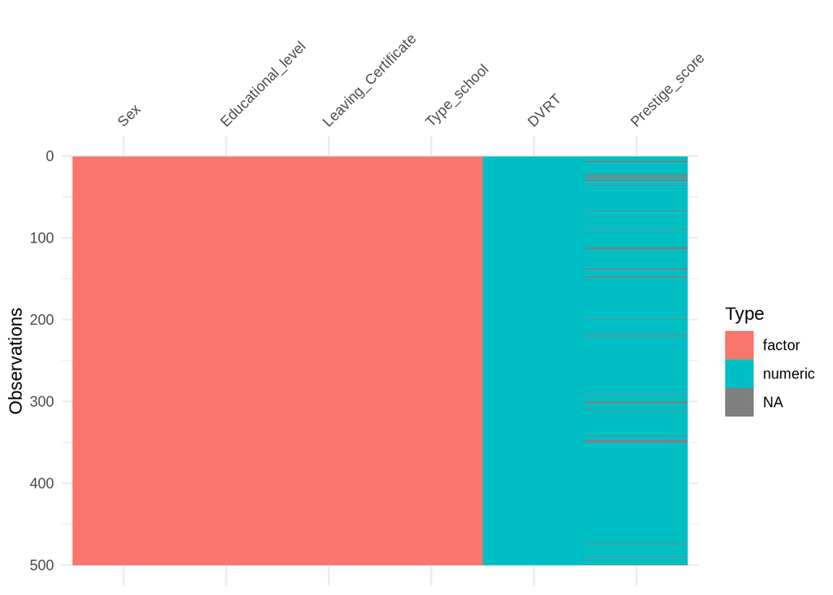

```r
vis_dat(dane)
```

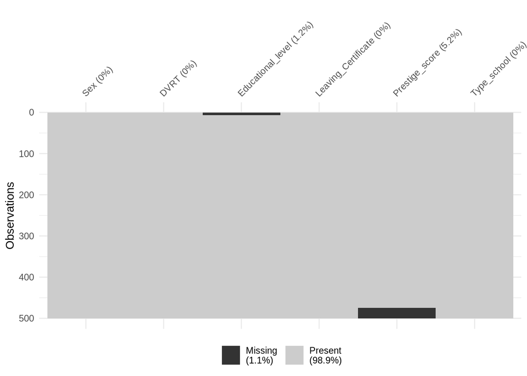

```r
# uwzględnijmy pytajnik jako NA
dane_bez_pytajnika <- dane
dane_bez_pytajnika$Educational_level[dane[,"Educational_level"] == "?"] <- NA
vis_miss(dane_bez_pytajnika, cluster = TRUE)
```

```r
# przyjmujemy te dane jako analizowane
dane <- dane_bez_pytajnika
```

# 2 Analiza

## 2.1 Histogramy

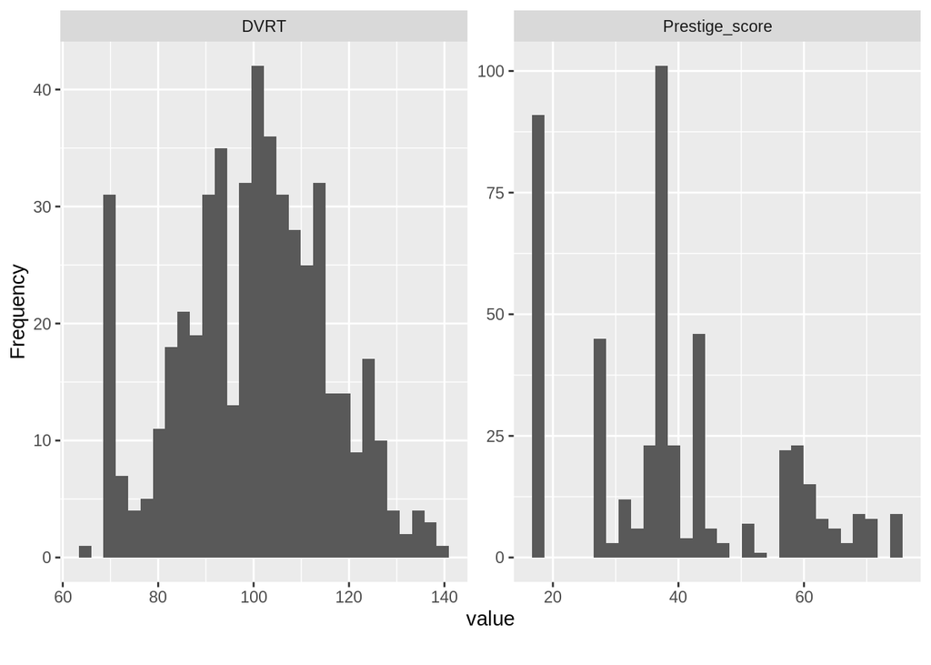

```r
DataExplorer::plot_histogram(dane)
```

W przypadku Prestige_score dużo nam to nie mówi, ale DVRT nieco przypomina rozkład normalny, czego moglibyśmy sie spodziewać - DVRT jest testem standaryzowanym.

## 2.2 Boxploty

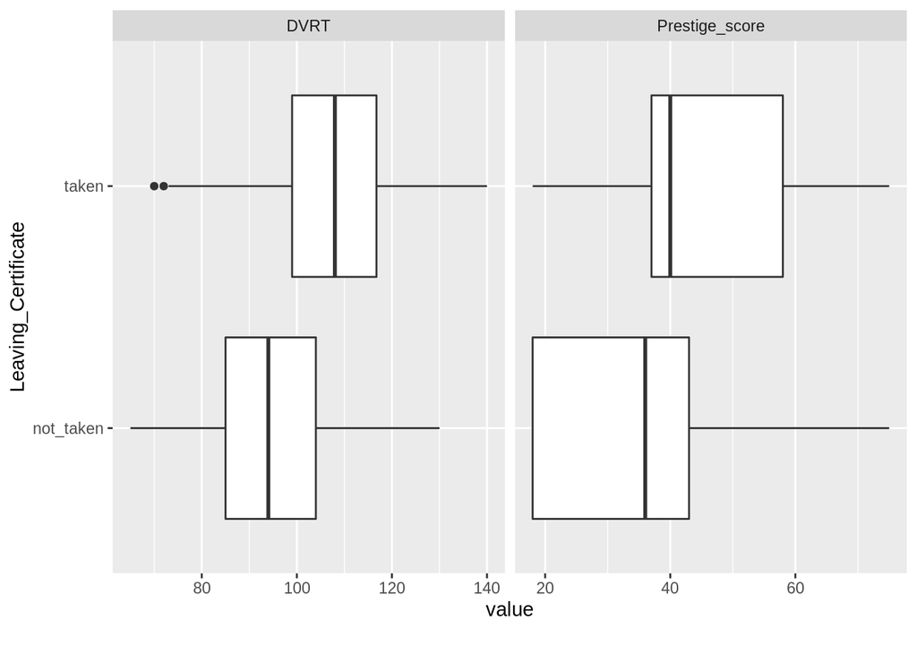

```r
DataExplorer::plot_boxplot(dane, by = "Leaving_Certificate")
```

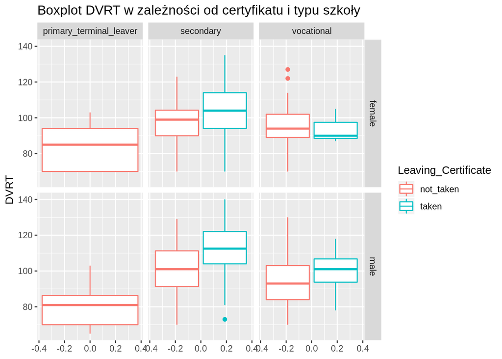

```r
ggplot(dane, aes(y = DVRT, color = Leaving_Certificate)) + geom_boxplot() + facet_grid(Sex~Type_school) + ggtitle("Boxplot DVRT w zależności od certyfikatu i typu szkoły")
```

Widać również pewną różnicę pomiędzy płciami - mężczyżni, który otrzymali certyfikat osiągnęli również średnio wyższe wyniki niż kobiety, które również otrzymały certyfikat.

## 2.3 Scatter plot

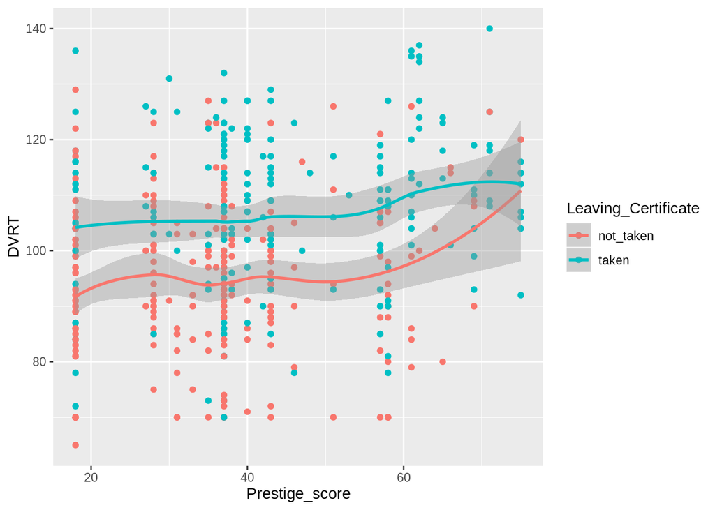

```r
clean_dane <- dane[!is.na(dane$Prestige_score),]
ggplot(clean_dane, aes(x= Prestige_score, y = DVRT, color = Leaving_Certificate)) + geom_point() + geom_smooth()
```

```r
cat("Współczynnik korelacji liniowej dla zmiennych DVRT oraz Prestige_score", cor(clean_dane$DVRT, clean_dane$Prestige_score))
```

```
## Współczynnik korelacji liniowej dla zmiennych DVRT oraz Prestige_score 0.2581569
```

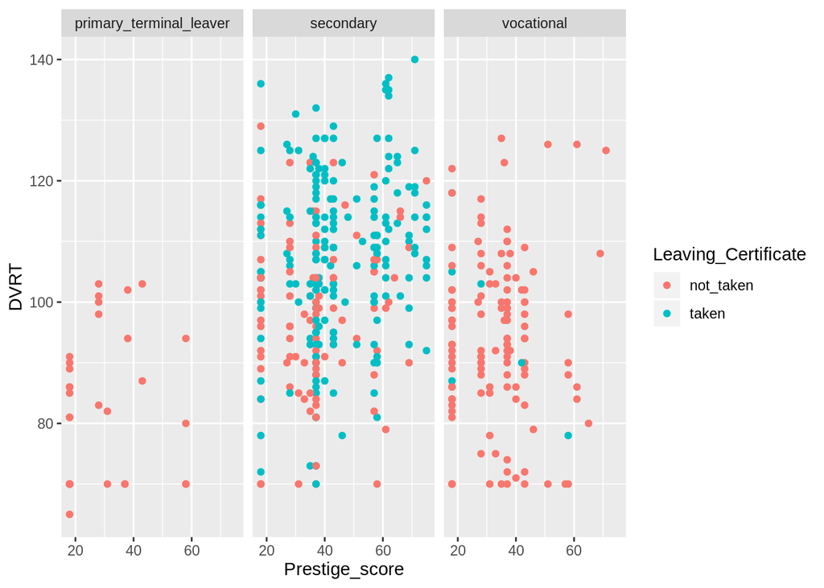

```r
ggplot(dane, aes(x= Prestige_score, y = DVRT, color = Leaving_Certificate)) + geom_point() + facet_wrap(~Type_school)
```

Znaczna część certyfikatów leży w rękach uczniów z type_school secondary, którzy osiągneli wyższe wyniki niż rówieśnicy.

## 2.4 Rozkłady zmiennych ciągłych

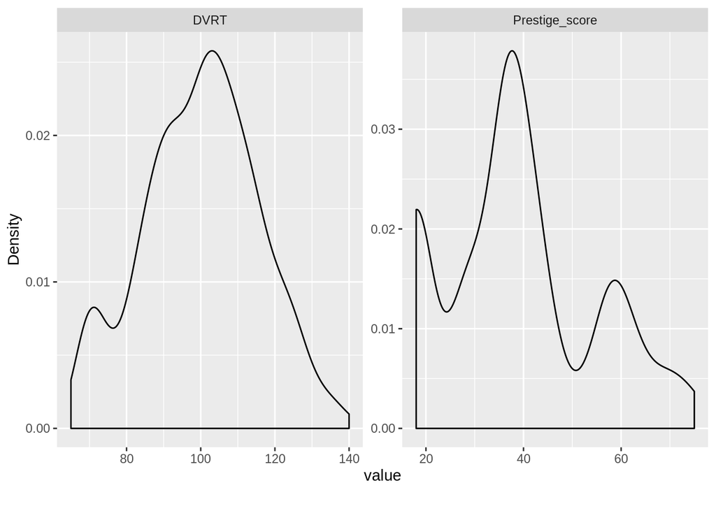

```r
d1 <- DataExplorer::plot_density(dane)
```

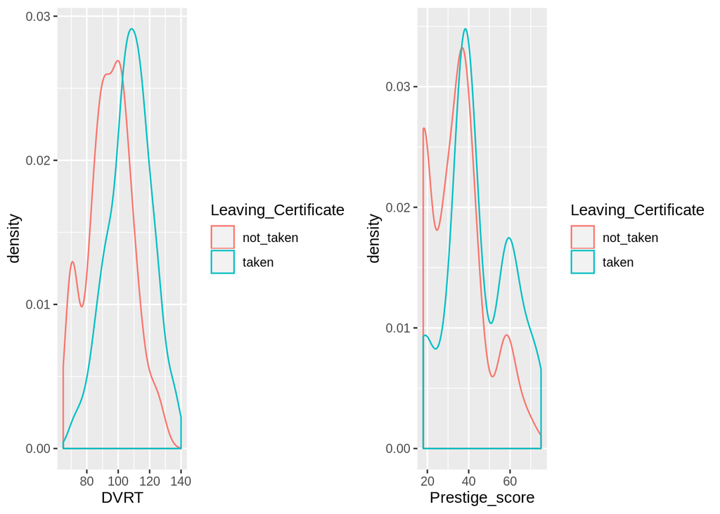

```r
d3 <- ggplot(dane, aes(x = DVRT, color = Leaving_Certificate)) + geom_density()
d4 <- ggplot(dane, aes(x = Prestige_score, color = Leaving_Certificate)) + geom_density()
(d3 + d4)
```

Można zauważyć, iż osoby o wyższym wyniku z DVRT i wyższym prestige_score są bardziej prawdopodobne do otrzymania certyfikatu.

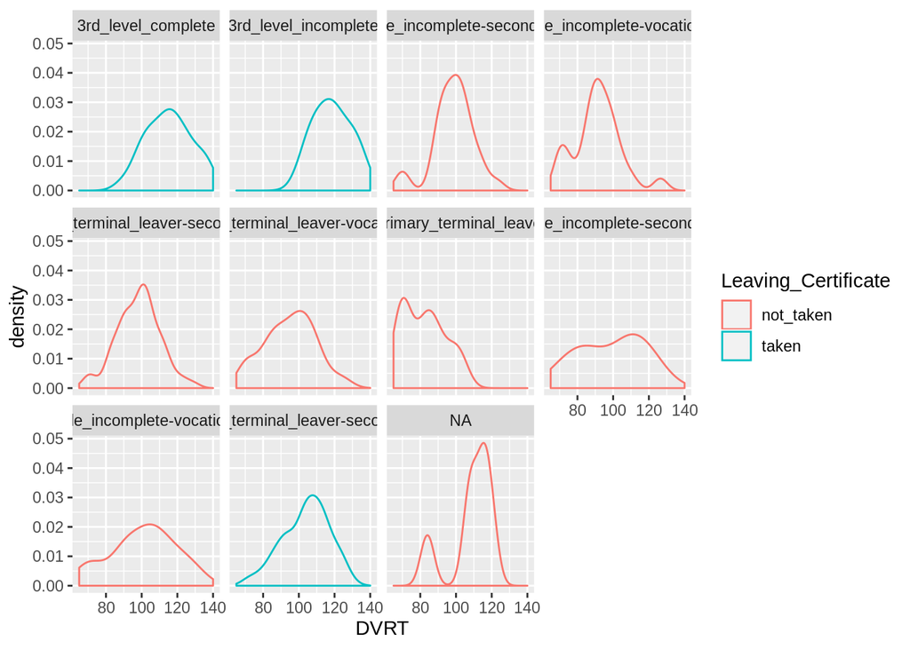

```r
ggplot(dane, aes(x=DVRT, color = Leaving_Certificate)) + geom_density() + facet_wrap(~Educational_level)
```

Przy wynikach DVRT - prawie rozkład normalny. Z ostatniego wykresu można zauważyć, iż tylko osoby z trzech kategorii dostały certyfikat:

- 3rd_level_complete
- 3rd_level_incomplete
- Senior_cycle_terminal_leaver-secondary_school

Przyjrzyjmy sie temu bliżej:

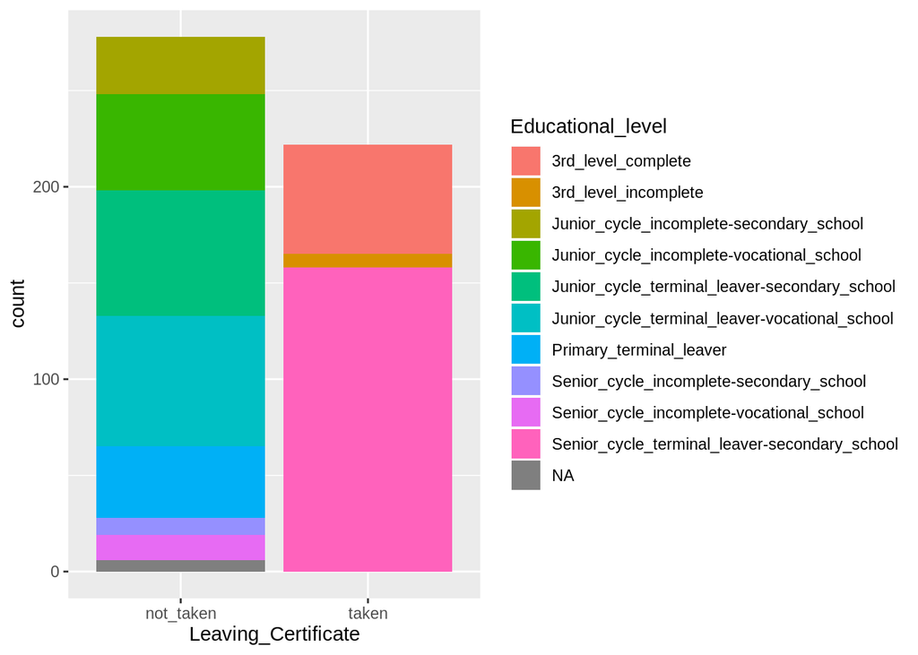

```r
df <- dane[, c("Leaving_Certificate", "Educational_level")]
ggplot(df, aes(x=Leaving_Certificate, fill = Educational_level)) + geom_bar()
```

```r
#table(df)
```

Jest to bardzo jasne rozgraniczenie, które może wynikać z metodyki badania - cerftyfikat mogły na przykład dostać osoby spełniające konkretne warunki dotyczące poziomu edukacji.

## 2.5 Korelacje

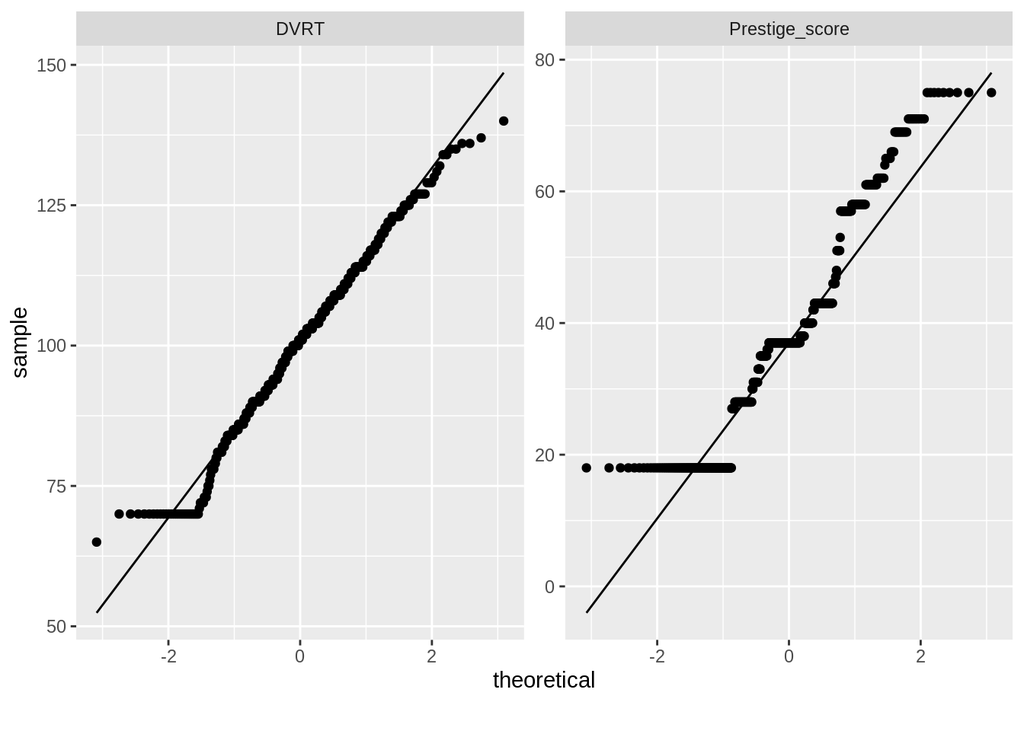

```r
DataExplorer::plot_qq(dane)
```

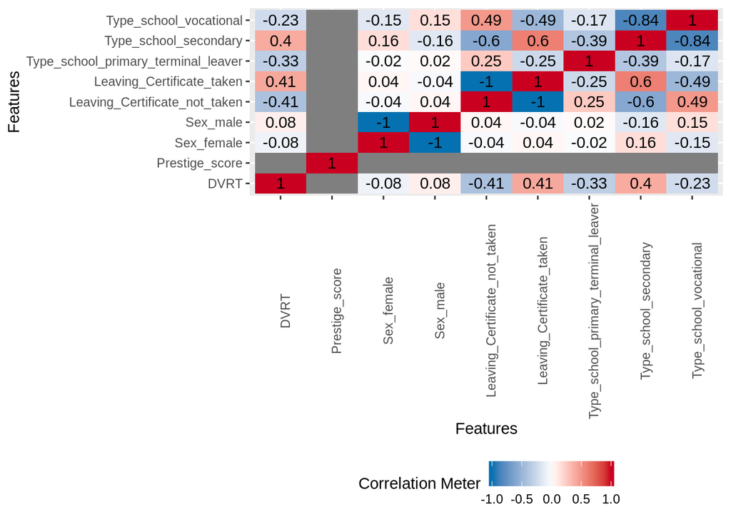

```r
DataExplorer::plot_correlation(dane[,-3])
```

Jak w przypadku boxplotów - DVRT nieco przypomina rozkład normalny. W korelacjach widać, iż silniej skorelowane są czynniki takie jak wyższy poziom edukacji(Type_school_secondary), otrzymanie certyfikatu oraz wynik DVRT. Ujemnie skorelowany jest niższy poziom edukacji(type_school_vocational), nieuzyskanie certyfikatu oraz wynii DVRT.

## 2.6 Podsumowanie

Nie ma co tu dużo pisać - osoby, które otrzymały leaving certificate, mają wyższe wykształcenie(na tle reszty, zbiór dotyczny 11-latków) osiągają średnio wyższe wyniki z DVRT. Nie ma wielkich różnic na tle płci. Strona źródłowa twierdzi, iż targetem jest Leaving_certificate, jednak wydaje sie być to mylne, biorąc pod uwagę, iż można to przewidzieć prostym if statmentem dotycznącym poziomu edukacji. Sądzę, że znaczenie bardziej interesującym problemem jest przewidzenie wyniku z DVRT.

# 3 Uzupełnienie danych

Dane uzupełnimy w następujący sposób: * usunięcie kolumn z brakującymi wartościmi * usunięcie wierszy z brakującymi wartościmi * zastępienie Educational_level modą lub oznaczenie jako “?” * zastąpienie Prestige_score średnią, medianą lub próbką

```r
df_remove_columns <- dane[, -which(colnames(dane) %in% c("Educational_level", "Prestige_score"))]
df_remove_rows <- na.omit(dane)

# Education_level <- "?"
df_pytajnik <- dane
df_pytajnik$Educational_level[is.na(df_pytajnik$Educational_level)] <- "?"

df_pytajnik_mean <- mice(df_pytajnik, method = "mean", m = 1, maxit = 1)
df_pytajnik_sample <- mice(df_pytajnik, method = "sample", m = 1, maxit = 1)
med <- median(df_pytajnik$Prestige_score, na.rm = T)
df_pytajnik_median <- df_pytajnik
df_pytajnik_median$Prestige_score[is.na(df_pytajnik_median$Prestige_score)] <- med

# Education_level <- moda

df_moda <- dane
df_moda$Educational_level[is.na(df_moda$Educational_level)] <- "Senior_cycle_terminal_leaver-secondary_school"

df_moda_mean <- mice(df_moda, method = "mean", m = 1, maxit = 1)
df_moda_sample <- mice(df_moda, method = "sample", m = 1, maxit = 1)
df_moda_median <- df_pytajnik
df_moda_median$Prestige_score[is.na(df_moda_median$Prestige_score)] <- med


dfs <- list(complete(df_pytajnik_mean), complete(df_pytajnik_sample), df_pytajnik_median, complete(df_moda_mean), complete(df_moda_sample), df_moda_median)
```

# 4 Model

## 4.1 Target Leaving_Certificate

```r
get_pred <- function(df, target){
  task = TaskClassif$new(id = "irish", backend = df, target = target)

  train_set = sample(task$nrow, 0.8 * task$nrow)
  test_set = setdiff(seq_len(task$nrow), train_set)

  learner = mlr_learners$get("classif.ranger")

  learner$train(task, row_ids = train_set)
  learner$predict(task, row_ids = test_set)
}

p <- get_pred(df = df_remove_columns, "Leaving_Certificate")
p$score()
```

```
## classif.ce
##        0.3
```

```r
p <- get_pred(df = df_remove_rows, "Leaving_Certificate")
p$score()
```

```
## classif.ce
##          0
```

```r
res <- lapply(dfs, function(x){p <- get_pred(x, "Leaving_Certificate"); p$score() })
res <- unlist(res )
res2 <- data.frame(pytajnik = res[1:3], moda = res[4:6])
rownames(res2) <- c("mean", "sample", "median")
res2
```

|  | pytajnik | moda |
| --- | --- | --- |
| mean | 0.00 | 0.00 |
| sample | 0.00 | 0.02 |
| median | 0.01 | 0.00 |

Jak widać jest to słaby target do przewidywania - jak dało się to wcześniej zauważyć zależy on tylko od kolumny Educational_level. Niezależnie od zamienienia na modę czy pytajnik nie zmienia to faktu, że wartości zamienione w kolumnie Educational_level nie dostaną certyfikat. Jeśli usuniemy całe kolumny dostaniemy duży błąd, a w reszcie przypadków zerowy bądź bardzo mały.

## 4.2 Target DVRT

Nietrywialnym problemem jest przewidywanie wyników z testu DVRT:

```r
get_pred <- function(df, target){
  task = TaskRegr$new(id = "irish", backend = df, target = target)

  train_set = sample(task$nrow, 0.8 * task$nrow)
  test_set = setdiff(seq_len(task$nrow), train_set)

  learner = mlr_learners$get("regr.ranger")
  learner$param_set
  learner$train(task, row_ids = train_set)
  learner$predict(task, row_ids = test_set)
}

p <- get_pred(df = df_remove_columns, "DVRT")
p$score()
```

```
## regr.mse
## 182.1668
```

```r
p <- get_pred(df = df_remove_rows, "DVRT")
p$score()
```

```
## regr.mse
## 147.3886
```

```r
res <- lapply(dfs, function(x){p <- get_pred(x, "DVRT"); p$score() })
res <- unlist(res )
res2 <- data.frame(pytajnik = res[1:3], moda = res[4:6])
rownames(res2) <- c("mean", "sample", "median")
res2
```

|  | pytajnik | moda |
| --- | --- | --- |
| mean | 138.5300 | 195.5732 |
| sample | 156.7923 | 182.1833 |
| median | 169.7230 | 226.9702 |